# Homework6

## 6. Numerical Elements -- Find your own 1D Oscillator (50pts)

We have built all the tools to study 1D unforced oscillators. Now you get to pick your own potential and study it. You can pick any 1D potential you like, but it should have a local minimum. Make sure it is not a driven oscillator (i.e., no explicit time dependence in the equations of motion).

Here are some examples that you can choose from:

1. **Simple Pendulum (Nonlinear Small Angle Approximation)**:
   - Potential: $ V(\theta) = mgh(1 - \cos(\theta)) $, where $m$ is the mass, $g$ is the acceleration due to gravity, $h$ is the length of the pendulum, and $\theta$ is the angular displacement.
2. **Nonlinear Spring (Hardening or Softening)**:
   - Potential: $ V(x) = \frac{k}{2} x^2 + \frac{\beta}{3} x^3 $, where $k$ and $\beta$ are constants. Depending on the sign of $\beta$, the spring can exhibit hardening ($\beta > 0$) or softening ($\beta < 0$) nonlinearity.
3. **Lennard-Jones Potential Oscillator** (for a diatomic molecule model):
   - Potential: $ V(r) = 4\epsilon \left[ \left(\frac{\sigma}{r}\right)^{12} - \left(\frac{\sigma}{r}\right)^6 \right] $, where $\epsilon$ is the depth of the potential well, $\sigma$ is the finite distance at which the inter-particle potential is zero, and $r$ is the distance between particles.
4. **Morse Potential (for molecular vibrations)**:
   - Potential: $ V(x) = D_e \left(1 - e^{-a(x - x_0)}\right)^2 $, where $D_e$ is the depth of the potential well, $a$ is a constant related to the width of the well, $x$ is the displacement from equilibrium, and $x_0$ is the equilibrium bond length. This potential models the energy of a diatomic molecule as a function of the distance between atoms, showing oscillatory behavior that represents molecular vibrations.
5. **Double Well Potential**:
   - Potential: $ V(x) = -\frac{\mu}{2} x^2 + \frac{\lambda}{4} x^4 $, where $\mu$ and $\lambda$ are positive constants. This system exhibits bistability with two stable equilibria, leading to interesting nonlinear dynamics and potential oscillations between the wells under certain conditions.

a. (5pts) Present the potential and describe its origin, why it is interesting, where it comes from, etc. Educate us about it.

# Part_A_5pts

**I chose the most simple one which is the simple pandulum. The reason I chose it is the most relatable example I can find, because you can find it almost everywhere from clocks to toys.A quick google search shows these clocks were actually a very huge improvement to timekeeping back in the 1600s, improving clock accuracy from 15 minutes per day to 15 seconds. We learn about them in our first physics class.**

b. (5pts) Plot the potential as a function of it's argument (and chosen variables) and find the equilibrium position of the potential, i.e. the position where the potential is at a minimum.

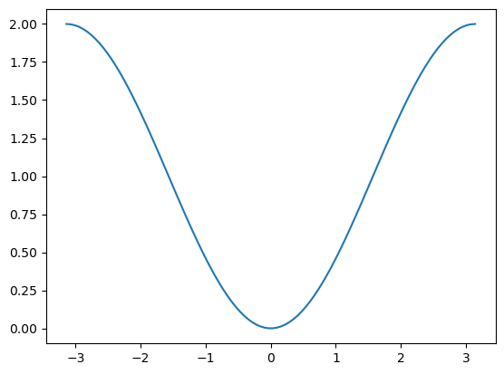

```python
#Part_B_5pts
import numpy as np
import matplotlib.pyplot as plt
from sympy import symbols, diff, solve

angle = np.linspace(-np.pi,np.pi,100)
plt.plot(angle,1-np.cos(angle))
plt.show()
```

c. (10pts) Rewrite the potential in terms of the displacement from equilibrium. Expand the potential to second order to find the effective spring constant, $k$, for the potential near the minimum. What is the frequency of small oscillations about the minimum?

d. (10pts) Construct the equations of motion for the potential and solve them numerically. Choose initial conditions and parameters that give oscillatory motion. Note it doesn't have to be SHO (In fact, it probably won't be). Plot the position as a function of time. Make sure we can see the oscillations.

heres the solution for $\frac{d^2\phi}{d\phi^2} =- \frac{g}{L} \sin(\phi)=0$. Instead of using the small angle approximation and getting out exactly SHO, I'll try a bit of a wider angle and see if something interesting happens

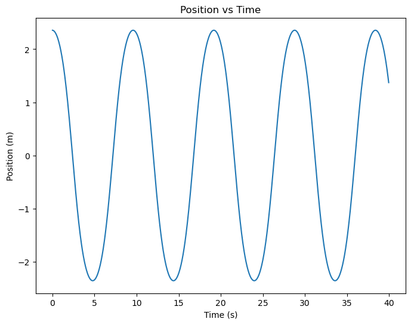

```python
import pandas as pd

def WSpen(X,V):

    # using g = L = 9.8
    dX = V
    dV = -np.sin(X)

    return dX, dV



def euler_cromer(x0, v0, t0, tf, dt):
    t = np.arange(t0, tf, dt)
    x = np.zeros(t.shape)
    v = np.zeros(t.shape)
    x[0], v[0] = x0, v0

    for i in range(1, len(t)):

        v[i] = v[i-1] - dt * np.sin(x[i-1])
        x[i] = x[i-1] + dt * v[i]

    return t, x, v

x0 = 3*np.pi / 4
v0 = 0
t0, tf = 0, 40
dt = 0.04

t, x ,v = euler_cromer(x0, v0, t0, tf, dt)
euler_cromerdf = pd.DataFrame({'t': t, 'x': x, 'v': v})

plt.figure(figsize=(8, 6))
plt.plot(euler_cromerdf['t'], euler_cromerdf['x'], label='Euler-Cromer')
plt.title('Position vs Time')
plt.xlabel('Time (s)')
plt.ylabel('Position (m)')
plt.show()
```

e. (10pts) Plot the phase diagram of the trajectory (you don't have to produce a phase diagram, but just plot the trajectory in phase space). What does the phase diagram tell you about the motion?

**there's two kinds of oscillation that can occur, one for when the pendulum gets all the way around, and one when it siwng back and forth.**

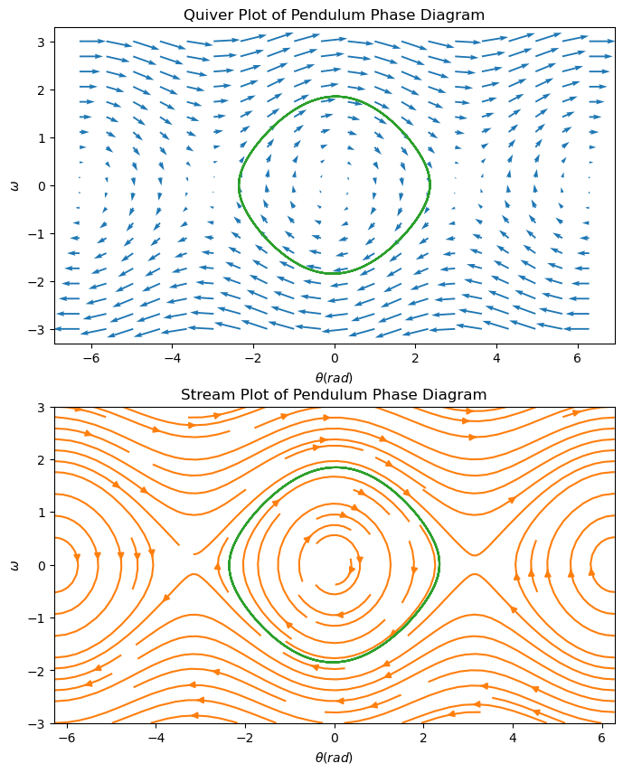

```python
#Part_E_10pts
def generate_phase_space(x_lim, v_lim, grid_size):

    x = np.linspace(x_lim[0], x_lim[1], grid_size)
    v = np.linspace(v_lim[0], v_lim[1], grid_size)

    X, V = np.meshgrid(x, v)

    dX, dV = WSpen(X,V)

    return X, V, dX, dV

# Generate phase space
theta_lim = (-np.pi * 2, np.pi * 2)
omega_lim = (-3, 3)
grid_size = 20
X, V, dX, dV = generate_phase_space(theta_lim, omega_lim, grid_size)


fig, axs = plt.subplots(2, 1, figsize=(8, 10))  # Two rows, one column

# Quiver plot on the first subplot
axs[0].quiver(X, V, dX, dV, color='C0')
axs[0].plot(euler_cromerdf['x'], euler_cromerdf['v'], label='Sample trajectory', c='C2')

axs[0].set_title('Quiver Plot of Pendulum Phase Diagram')
axs[0].set_xlabel(r'$\theta (rad)$')
axs[0].set_ylabel(r'$\omega$')

# Stream plot on the second subplot
axs[1].streamplot(X, V, dX, dV, color='C1')
axs[1].plot(euler_cromerdf['x'], euler_cromerdf['v'], label='Sample trajectory', c='C2')

axs[1].set_title('Stream Plot of Pendulum Phase Diagram')
axs[1].set_xlabel(r'$\theta (rad)$')
axs[1].set_ylabel(r'$\omega$');
```

f. (10pts) Find the period of your motion. Here you might have to make some definitions of what periodicity means for your potential.

```python
#Part_F_10pts

#6f already covered in 2c
```

[output not shown]

[output not shown]